# Exploratory Data Analysis (EDA) in Python

# **Introduction**

Exploratory Data Analysis of the famous Iris dataset.

The features present in the dataset are:

```
Sepal Width
Sepal Length
Petal Width
Petal Length
```

The target "species" has 3 classes namely 'setosa', 'versicolor', and 'virginica'.

initial EDA

How: Using powerfull python moduls [pandas, matplotlib, and seaborn]

```python
# importing pandas, and other necessary modules
import pandas as pd
import matplotlib.pyplot as plt
import seaborn as sns
import numpy as np
```

Trong bước đầu tiên của quá trình phân tích dữ liệu, ta cần nhập (import) các thư viện cần thiết để hỗ trợ thao tác, xử lý và trực quan hóa dữ liệu:

pandas (pd): dùng để xử lý dữ liệu dạng bảng (DataFrame), giúp đọc, ghi, làm sạch và phân tích dữ liệu dễ dàng.

numpy (np): cung cấp các công cụ toán học và xử lý mảng số học hiệu quả, thường được dùng để tính toán hoặc chuẩn hóa dữ liệu.

matplotlib.pyplot (plt): hỗ trợ vẽ các biểu đồ cơ bản như histogram, scatter plot, line chart, phục vụ trực quan dữ liệu.

seaborn (sns): xây dựng dựa trên matplotlib, cho phép tạo các biểu đồ thống kê chuyên sâu, trực quan và dễ nhìn hơn.

Bốn thư viện này là nền tảng quan trọng trong hầu hết các dự án phân tích dữ liệu và machine learning bằng Python.

# **Load the dataset**

```python
df=sns.load_dataset('iris')
```

```python
#Alternative
'''
from sklearn import datasets
iris = datasets.load_iris()
X = iris.data
y = iris.target
iris_df=pd.DataFrame(X, columns=iris.feature_names)
iris_df['target']=y
'''
```

```
"\nfrom sklearn import datasets\niris = datasets.load_iris()\nX = iris.data\ny = iris.target\niris_df=pd.DataFrame(X, columns=iris.feature_names)\niris_df['target']=y\n"
```

**Mục đích:**  
Đoạn code này là cách thay thế để tải bộ dữ liệu *Iris* từ thư viện `scikit-learn`.  
Cụ thể, nó:

- Tải dữ liệu hoa Iris và tách thành phần đặc trưng (`X`) và nhãn (`y`).
- Tạo một `DataFrame` chứa 4 đặc trưng của hoa và thêm cột `target` thể hiện loài hoa.  
  Kết quả là một bảng dữ liệu hoàn chỉnh để dùng cho các bài toán phân tích hoặc phân loại.

# **A first look and non-graphical EDA**

```python
df
```

|  | sepal_length | sepal_width | petal_length | petal_width | species |
| --- | --- | --- | --- | --- | --- |
| 0 | 5.1 | 3.5 | 1.4 | 0.2 | setosa |
| 1 | 4.9 | 3.0 | 1.4 | 0.2 | setosa |
| 2 | 4.7 | 3.2 | 1.3 | 0.2 | setosa |
| 3 | 4.6 | 3.1 | 1.5 | 0.2 | setosa |
| 4 | 5.0 | 3.6 | 1.4 | 0.2 | setosa |
| ... | ... | ... | ... | ... | ... |
| 145 | 6.7 | 3.0 | 5.2 | 2.3 | virginica |
| 146 | 6.3 | 2.5 | 5.0 | 1.9 | virginica |
| 147 | 6.5 | 3.0 | 5.2 | 2.0 | virginica |
| 148 | 6.2 | 3.4 | 5.4 | 2.3 | virginica |
| 149 | 5.9 | 3.0 | 5.1 | 1.8 | virginica |

150 rows × 5 columns

```python
df.loc[10], df.iloc[2]
```

```
(sepal_length       5.4
 sepal_width        3.7
 petal_length       1.5
 petal_width        0.2
 species         setosa
 Name: 10, dtype: object,
 sepal_length       4.7
 sepal_width        3.2
 petal_length       1.3
 petal_width        0.2
 species         setosa
 Name: 2, dtype: object)
```

**Mục đích:**  
Đoạn code này minh họa sự khác biệt giữa hai cách truy cập dữ liệu trong `pandas`:

- `df.loc[10]`: truy cập **dòng có nhãn (label)** là `10`.
- `df.iloc[2]`: truy cập **dòng theo vị trí chỉ mục (index position)** thứ `2` (tính từ 0).  
  Cả hai đều trả về dữ liệu của một hàng trong DataFrame, nhưng dùng hai cơ chế định vị khác nhau.

```python
df.shape # Xem kích thước bộ dữ liệu
```

```
(150, 5)
```

```python
df.head()  # Xem nhanh 5 dòng đầu của dataframe
```

|  | sepal_length | sepal_width | petal_length | petal_width | species |
| --- | --- | --- | --- | --- | --- |
| 0 | 5.1 | 3.5 | 1.4 | 0.2 | setosa |
| 1 | 4.9 | 3.0 | 1.4 | 0.2 | setosa |
| 2 | 4.7 | 3.2 | 1.3 | 0.2 | setosa |
| 3 | 4.6 | 3.1 | 1.5 | 0.2 | setosa |
| 4 | 5.0 | 3.6 | 1.4 | 0.2 | setosa |

More details: the types of variables

```python
df.info() #Xem thông tin của bộ dữ liệ về các cột, kiểu dữ liệu, kích thước
```

```
<class 'pandas.core.frame.DataFrame'>
RangeIndex: 150 entries, 0 to 149
Data columns (total 5 columns):
 #   Column        Non-Null Count  Dtype
---  ------        --------------  -----
 0   sepal_length  150 non-null    float64
 1   sepal_width   150 non-null    float64
 2   petal_length  150 non-null    float64
 3   petal_width   150 non-null    float64
 4   species       150 non-null    object
dtypes: float64(4), object(1)
memory usage: 6.0+ KB
```

Check the null/na values

```python
df.isnull().sum() #Thống kê só dữ liệu bị trống của data
```

```
sepal_length    0
sepal_width     0
petal_length    0
petal_width     0
species         0
dtype: int64
```

```python
df.isnull().sum()
```

```
sepal_length    0
sepal_width     0
petal_length    0
petal_width     0
species         0
dtype: int64
```

**What are the stats of the variables?**

```python
df.describe() #Thống kê mô tả cho các biến số về mean,mã,min,std,tứ phân vị..
```

|  | sepal_length | sepal_width | petal_length | petal_width |
| --- | --- | --- | --- | --- |
| count | 150.000000 | 150.000000 | 150.000000 | 150.000000 |
| mean | 5.843333 | 3.057333 | 3.758000 | 1.199333 |
| std | 0.828066 | 0.435866 | 1.765298 | 0.762238 |
| min | 4.300000 | 2.000000 | 1.000000 | 0.100000 |
| 25% | 5.100000 | 2.800000 | 1.600000 | 0.300000 |
| 50% | 5.800000 | 3.000000 | 4.350000 | 1.300000 |
| 75% | 6.400000 | 3.300000 | 5.100000 | 1.800000 |
| max | 7.900000 | 4.400000 | 6.900000 | 2.500000 |

## Are the classes (species) balanced?

```python
df['species'] #Gọi tên 1 cột
```

```
0         setosa
1         setosa
2         setosa
3         setosa
4         setosa
         ...
145    virginica
146    virginica
147    virginica
148    virginica
149    virginica
Name: species, Length: 150, dtype: object
```

```python
from sklearn.preprocessing import LabelEncoder
encoder = LabelEncoder()
encoder.fit(df['species'])
```

```
LabelEncoder()
```

**Mục đích:**  
Đoạn code này sử dụng `LabelEncoder` từ thư viện `scikit-learn` để **mã hóa nhãn phân loại (categorical labels)** trong cột `species` của DataFrame.  
Cụ thể:

- `encoder = LabelEncoder()`: khởi tạo bộ mã hóa.
- `encoder.fit(df['species'])`: học và ánh xạ từng giá trị nhãn (ví dụ: `setosa`, `versicolor`, `virginica`) thành các giá trị số tương ứng (`0`, `1`, `2`).  
  Việc này giúp chuẩn bị dữ liệu dạng chuỗi để có thể sử dụng trong các mô hình machine learning.

```python
encoder.classes_
```

```
array(['setosa', 'versicolor', 'virginica'], dtype=object)
```

**Mục đích:**  
Lệnh `encoder.classes_` hiển thị **danh sách các nhãn (class labels)** mà `LabelEncoder` đã học được từ cột `species`.  
Kết quả sẽ là một mảng chứa các tên loài hoa (ví dụ: `['setosa', 'versicolor', 'virginica']`), tương ứng với thứ tự mã hóa số mà bộ mã hóa đã gán.

```python
df['class'] = encoder.transform(df['species'])
```

**Mục đích:**  
Dòng code này tạo thêm một cột mới `class` trong DataFrame để **lưu trữ giá trị số** tương ứng với nhãn loài hoa sau khi mã hóa.  
Cụ thể:

- `encoder.transform(df['species'])` chuyển các tên loài (`setosa`, `versicolor`, `virginica`) thành các số (`0`, `1`, `2`).
- `df['class'] = ...` gán kết quả này vào cột mới `class`, giúp dữ liệu sẵn sàng cho các mô hình học máy yêu cầu đầu vào dạng số.

```python
np.unique(df['species']) # Xem các giá trị có trong cột
```

```
array(['setosa', 'versicolor', 'virginica'], dtype=object)
```

```python
df['species'].apply(lambda x: x.upper())
```

```
0         SETOSA
1         SETOSA
2         SETOSA
3         SETOSA
4         SETOSA
         ...
145    VIRGINICA
146    VIRGINICA
147    VIRGINICA
148    VIRGINICA
149    VIRGINICA
Name: species, Length: 150, dtype: object
```

```python
df[["sepal_length","sepal_width","petal_length","petal_width", "class"]].corr()
```

|  | sepal_length | sepal_width | petal_length | petal_width | class |
| --- | --- | --- | --- | --- | --- |
| sepal_length | 1.000000 | -0.117570 | 0.871754 | 0.817941 | 0.782561 |
| sepal_width | -0.117570 | 1.000000 | -0.428440 | -0.366126 | -0.426658 |
| petal_length | 0.871754 | -0.428440 | 1.000000 | 0.962865 | 0.949035 |
| petal_width | 0.817941 | -0.366126 | 0.962865 | 1.000000 | 0.956547 |
| class | 0.782561 | -0.426658 | 0.949035 | 0.956547 | 1.000000 |

**Mục đích:**  
Đoạn code này tính **ma trận tương quan (correlation matrix)** giữa các biến định lượng trong DataFrame.  
Cụ thể, nó xem xét mối quan hệ tuyến tính giữa các cột: `sepal_length`, `sepal_width`, `petal_length`, `petal_width` và `class`.  
Kết quả là một bảng hiển thị **hệ số tương quan Pearson** (giá trị từ -1 đến 1), giúp xác định mức độ và chiều hướng tương quan giữa các đặc trưng và nhãn phân loại.

```python
df['species'].value_counts()
```

```
species
setosa        50
versicolor    50
virginica     50
Name: count, dtype: int64
```

**Mục đích:**  
Đoạn code này đếm **số lượng mẫu thuộc từng loài hoa** trong cột `species` của DataFrame.  
Lệnh `df['species'].value_counts()` trả về một bảng tóm tắt cho biết mỗi loài (ví dụ: `setosa`, `versicolor`, `virginica`) xuất hiện bao nhiêu lần trong bộ dữ liệu, giúp kiểm tra **phân bố nhãn (class distribution)** trước khi huấn luyện mô hình.

## Correlation Between Variables

```python
df[["sepal_length","sepal_width","petal_length","petal_width", "class"]].corr().sort_values(by='class', ascending=False)
```

|  | sepal_length | sepal_width | petal_length | petal_width | class |
| --- | --- | --- | --- | --- | --- |
| class | 0.782561 | -0.426658 | 0.949035 | 0.956547 | 1.000000 |
| petal_width | 0.817941 | -0.366126 | 0.962865 | 1.000000 | 0.956547 |
| petal_length | 0.871754 | -0.428440 | 1.000000 | 0.962865 | 0.949035 |
| sepal_length | 1.000000 | -0.117570 | 0.871754 | 0.817941 | 0.782561 |
| sepal_width | -0.117570 | 1.000000 | -0.428440 | -0.366126 | -0.426658 |

**Mục đích:**  
Đoạn code này tính **ma trận tương quan** giữa các biến định lượng và **sắp xếp theo mức độ tương quan với biến `class`** (nhãn loài hoa).  
Cụ thể:

- `.corr()` tính hệ số tương quan Pearson giữa các cột.
- `.sort_values(by='class', ascending=False)` sắp xếp các đặc trưng theo **mức độ liên hệ mạnh đến yếu** với biến `class`.  
  Kết quả giúp xác định **đặc trưng nào ảnh hưởng mạnh nhất đến việc phân loại loài hoa** trong bộ dữ liệu.

```python
df[["sepal_length","sepal_width","petal_length","petal_width", "class"]].corr()
```

|  | sepal_length | sepal_width | petal_length | petal_width | class |
| --- | --- | --- | --- | --- | --- |
| sepal_length | 1.000000 | -0.117570 | 0.871754 | 0.817941 | 0.782561 |
| sepal_width | -0.117570 | 1.000000 | -0.428440 | -0.366126 | -0.426658 |
| petal_length | 0.871754 | -0.428440 | 1.000000 | 0.962865 | 0.949035 |
| petal_width | 0.817941 | -0.366126 | 0.962865 | 1.000000 | 0.956547 |
| class | 0.782561 | -0.426658 | 0.949035 | 0.956547 | 1.000000 |

**Mục đích:**  
Đoạn code này tính **ma trận tương quan Pearson** giữa các biến định lượng trong DataFrame, bao gồm:  
`sepal_length`, `sepal_width`, `petal_length`, `petal_width` và `class`.

Kết quả hiển thị mức độ tương quan (từ -1 đến 1) giữa từng cặp biến, giúp xác định:

- Mối quan hệ tuyến tính giữa các đặc trưng.
- Đặc trưng nào có liên hệ mạnh nhất với biến phân loại (`class`) để phục vụ phân tích hoặc huấn luyện mô hình.

# **Graphical EDA**

Let's start from where we reached for the non-graphical EDA

## **Are the classes (species) balanced?**

### Using pandas

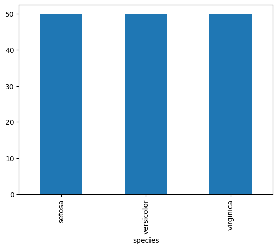

```python
df["species"].value_counts().plot.bar()
```

**Mục đích:**  
Đoạn code này vẽ **biểu đồ cột (bar chart)** thể hiện **tần suất xuất hiện của từng loài hoa** trong cột `species`.  
Cụ thể:

- `df["species"].value_counts()` đếm số mẫu của mỗi loài.
- `.plot.bar()` trực quan hóa kết quả dưới dạng biểu đồ cột.

Biểu đồ giúp quan sát nhanh **sự phân bố dữ liệu giữa các lớp (class balance)**, hỗ trợ đánh giá xem bộ dữ liệu có bị mất cân bằng hay không.

### Using matplotlib

```
<BarContainer object of 3 artists>
```

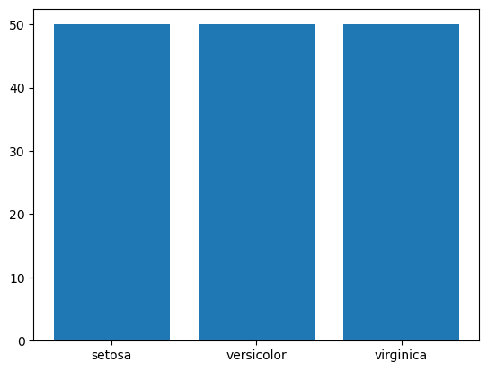

```python
#we can use bar chart
counts = df["species"].value_counts()
plt.bar(counts.index, counts.values)
```

**Mục đích:**  
Đoạn code này vẽ **biểu đồ cột (bar chart)** hiển thị **số lượng mẫu của từng loài hoa** trong cột `species`.  
Cụ thể:

- `df["species"].value_counts()` đếm số lượng mẫu của mỗi loài và lưu vào `counts`.
- `plt.bar(counts.index, counts.values)` dùng `matplotlib` để vẽ biểu đồ, trong đó:
  - Trục X hiển thị tên các loài hoa.
  - Trục Y thể hiện số lượng mẫu tương ứng.

Biểu đồ giúp minh họa **phân bố dữ liệu theo từng lớp** một cách trực quan.

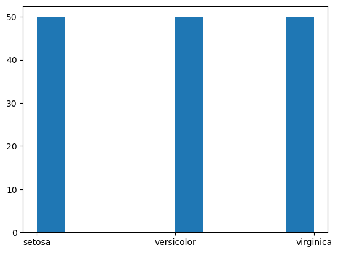

```python
#one way using histogram :)
plt.hist(df['species'])
```

**Mục đích:**  
Đoạn code này sử dụng **biểu đồ tần suất (histogram)** để minh họa **phân bố của biến `species`** trong bộ dữ liệu.  
Cụ thể:

- `plt.hist(df['species'])` vẽ biểu đồ hiển thị số lượng mẫu của từng loài hoa.

Tuy nhiên, vì `species` là **biến phân loại (categorical)** chứ không phải **biến số liên tục**, nên biểu đồ cột (`bar chart`) sẽ phù hợp và trực quan hơn so với histogram.

### Using seaborn

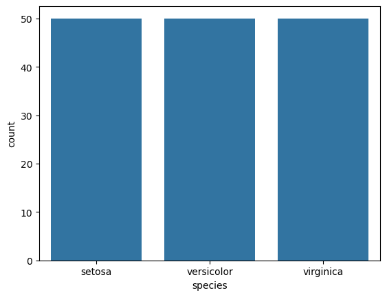

```python
sns.countplot(x = df['species']);
```

**Mục đích:**  
Đoạn code này sử dụng **`seaborn`** để vẽ **biểu đồ đếm (count plot)**, thể hiện **số lượng mẫu của từng loài hoa** trong biến `species`.  
Cụ thể:

- `sns.countplot(x=df['species'])` tự động đếm số mẫu cho mỗi loài và hiển thị dưới dạng các cột.
- Dấu `;` ở cuối giúp ẩn phần output không cần thiết khi chạy trong notebook.

Biểu đồ này trực quan, dễ nhìn và thường được dùng để **kiểm tra sự cân bằng giữa các lớp dữ liệu (class distribution)**.

### What we can conclude:

- Classes are balanced
- It is safe to use different classification accuracy metrics
- No pre-processing setps are required to address data imbalance (augmentation, oversampling, downsampling)
- ...

## **Comparison graphs**

### Scatterplots

What?

- use a Cartesian coordinates system to display values of typically two variables for a set of data

Why?

- show the relationship between two variables

Let's try an example:

Showing the scatterplot between the features 'sepal_length' and 'sepal_width'

### Scatterplot using pandas

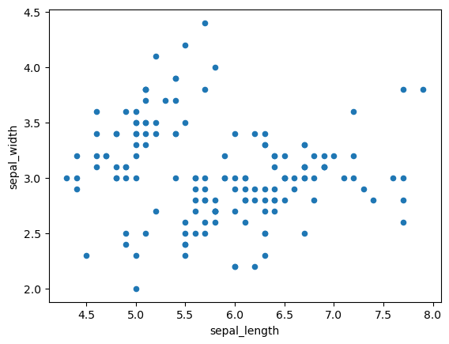

```python
df.plot.scatter('sepal_length','sepal_width')
```

**Mục đích:**  
Đoạn code này vẽ **biểu đồ phân tán (scatter plot)** giữa hai biến `sepal_length` và `sepal_width`.  
Cụ thể:

- `df.plot.scatter('sepal_length', 'sepal_width')` tạo biểu đồ với:
  - Trục X biểu diễn chiều dài đài hoa (`sepal_length`).
  - Trục Y biểu diễn chiều rộng đài hoa (`sepal_width`).

Biểu đồ giúp quan sát **mối quan hệ tuyến tính hoặc xu hướng phân tách giữa hai đặc trưng**, hỗ trợ phát hiện các cụm dữ liệu hoặc ngoại lệ (outliers).

### Scatterplot using matplotlib

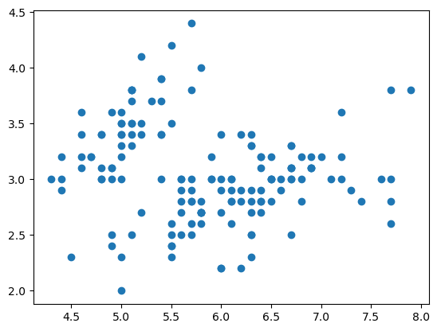

```python
plt.scatter('sepal_length', 'sepal_width', data=df)
```

**Mục đích:**  
Đoạn code này vẽ **biểu đồ phân tán (scatter plot)** giữa hai biến `sepal_length` và `sepal_width` bằng thư viện **Matplotlib**.  
Cụ thể:

- `plt.scatter('sepal_length', 'sepal_width', data=df)` sử dụng dữ liệu từ DataFrame `df`,
  - Trục X biểu diễn `sepal_length` (chiều dài đài hoa).
  - Trục Y biểu diễn `sepal_width` (chiều rộng đài hoa).

Biểu đồ này giúp trực quan hóa **mối quan hệ giữa hai đặc trưng** và có thể cho thấy xu hướng, cụm hoặc điểm ngoại lệ trong dữ liệu.

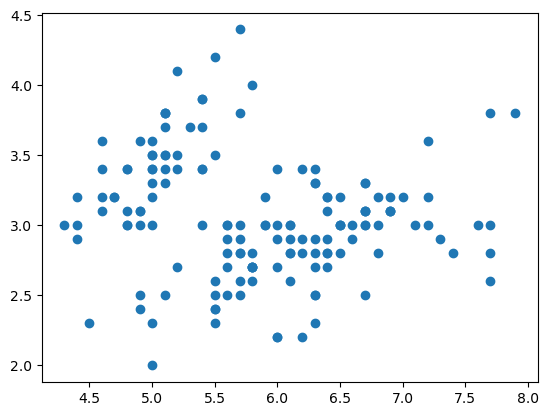

```python
plt.scatter(df['sepal_length'], df['sepal_width'])
```

**Mục đích:**  
Vẽ biểu đồ phân tán (scatter plot) giữa hai biến `sepal_length` (trục X) và `sepal_width` (trục Y) để trực quan hóa mối quan hệ, tìm xu hướng, cụm dữ liệu hoặc các điểm ngoại lai giữa hai đặc trưng.

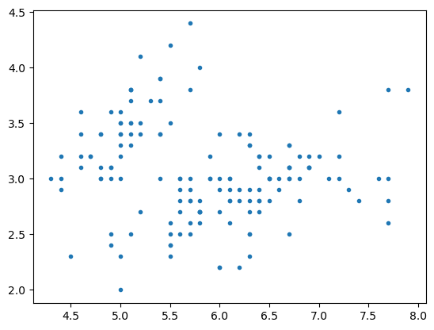

```python
#using plt
plt.plot('sepal_length', 'sepal_width', data=df, marker='.',linestyle='none')
```

**Mục đích:**  
Sử dụng `plt.plot()` để vẽ biểu đồ phân tán giữa `sepal_length` và `sepal_width`, trong đó `marker='.'` hiển thị các điểm dữ liệu riêng lẻ và `linestyle='none'` loại bỏ đường nối giữa các điểm.  
Biểu đồ giúp quan sát mối quan hệ giữa hai đặc trưng một cách trực quan.

### Scatterplot using seaborn

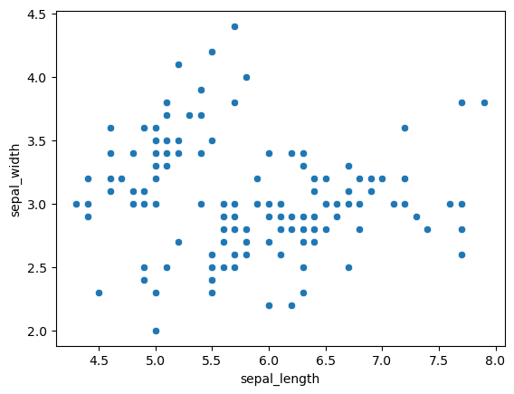

```python
sns.scatterplot(x = df['sepal_length'], y = df['sepal_width'])
#or sns.scatter('sepal_length', 'sepal_width', data=df)
```

**Mục đích:**  
Vẽ **biểu đồ phân tán (scatter plot)** giữa `sepal_length` và `sepal_width` bằng thư viện **Seaborn**, giúp hiển thị mối quan hệ tuyến tính hoặc phi tuyến giữa hai biến.  
Mỗi điểm biểu thị một mẫu hoa trong tập dữ liệu, hỗ trợ nhận biết xu hướng hoặc sự phân cụm của dữ liệu.

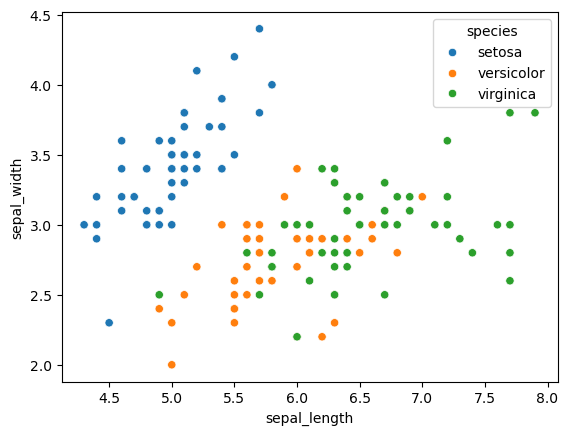

```python
# With respect to the target class (species)
sns.scatterplot(x = 'sepal_length', y = 'sepal_width', hue=df['species'], data=df)
```

**Mục đích:**  
Vẽ **biểu đồ phân tán có phân loại (scatter plot with hue)** thể hiện mối quan hệ giữa `sepal_length` và `sepal_width`, đồng thời **phân biệt các loài hoa** thông qua màu sắc (`hue=df['species']`).

Biểu đồ này giúp quan sát rõ ràng **sự khác biệt và phân tách giữa các loài hoa** dựa trên hai đặc trưng này.

## **Correlogram**

Correlogram: AKS correlation matrix, to analyse the relationship between each pair of numeric variables

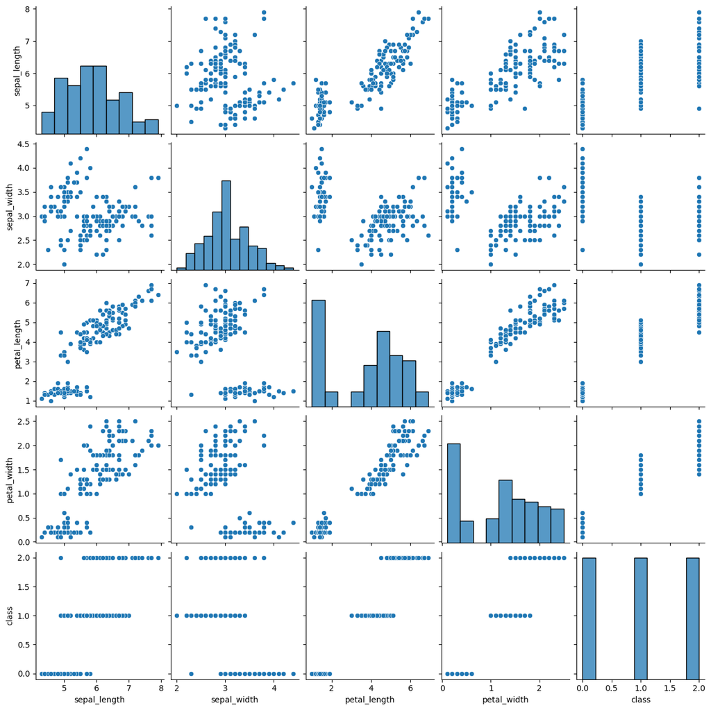

```python
sns.pairplot(df)
```

**Mục đích:**  
Lệnh `sns.pairplot(df)` vẽ **biểu đồ ma trận (pair plot)** cho toàn bộ các cặp biến trong DataFrame.

Cụ thể:

- Mỗi ô trong ma trận là **biểu đồ phân tán** thể hiện mối quan hệ giữa hai biến.
- Đường chéo chính hiển thị **biểu đồ phân phối (histogram)** của từng biến.

Biểu đồ này giúp **phát hiện mối tương quan, xu hướng hoặc khả năng phân tách giữa các đặc trưng** trong tập dữ liệu.

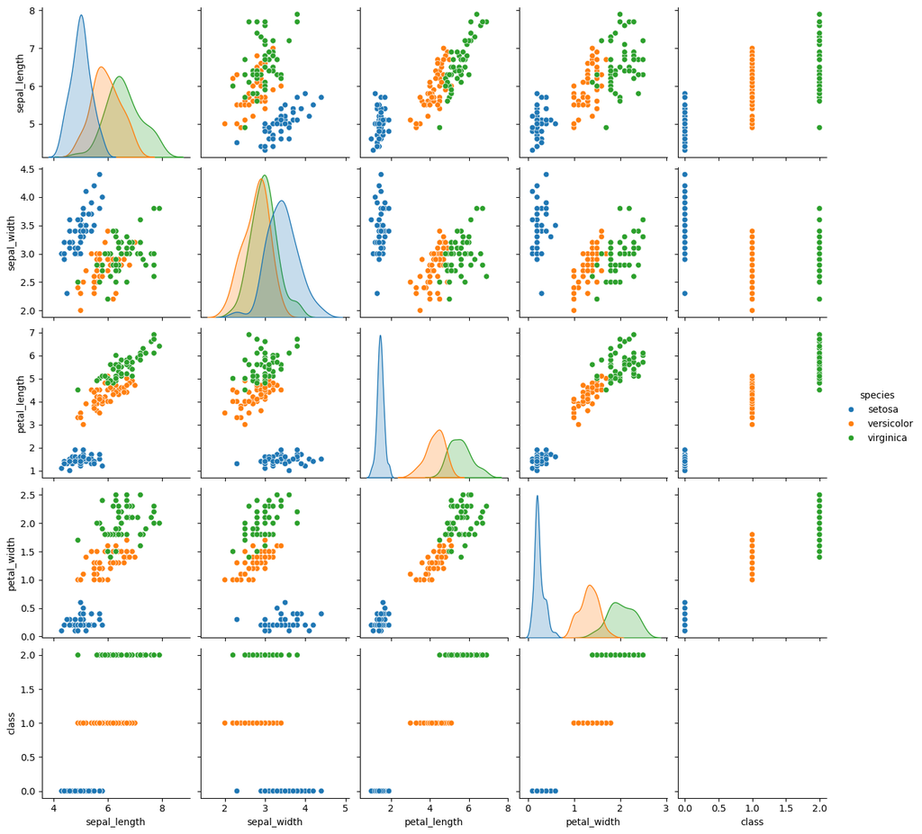

```python
sns.pairplot(df,hue="species")
```

**Mục đích:**  
Lệnh `sns.pairplot(df, hue="species")` vẽ **biểu đồ ma trận (pair plot)** cho tất cả các cặp biến, **phân biệt màu sắc theo loài hoa (`species`)**.

Cụ thể:

- Mỗi cặp biến được hiển thị dưới dạng **biểu đồ phân tán**.
- Các điểm dữ liệu được **tô màu khác nhau cho từng loài hoa**, giúp quan sát khả năng phân biệt giữa các lớp.
- Đường chéo chính hiển thị **phân phối riêng của từng biến** theo từng loài.

Biểu đồ này giúp **trực quan hóa mối quan hệ và mức độ tách biệt giữa các loài trong tập dữ liệu**.

## **Heatmap**

Further, we can visualise this correlation using a heatmap.

Heatmap: a two-dimensional graphical representation of data where the individual values that are contained in a matrix are represented as colors

useful to see which intersections of the categorical values, have higher concentration of the data compared to the others

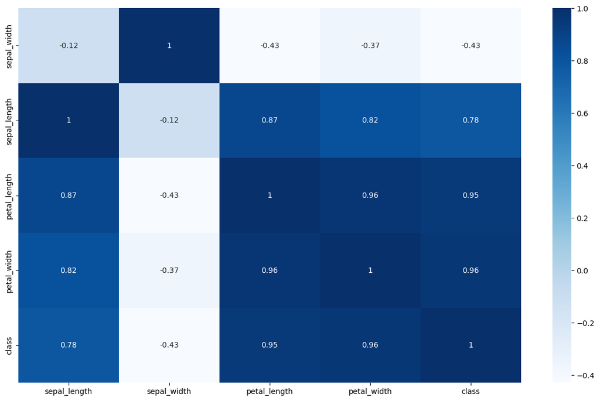

```python
fig = plt.figure(figsize = (15,9))
sns.heatmap(df[["sepal_length","sepal_width","petal_length","petal_width", "class"]].corr().sort_values(by="class"), cmap='Blues', annot = True);
```

**Mục đích:**  
Đoạn code này vẽ **biểu đồ nhiệt (heatmap)** thể hiện **ma trận tương quan giữa các biến định lượng** trong tập dữ liệu.

Cụ thể:

- `df[["sepal_length","sepal_width","petal_length","petal_width","class"]].corr()` tính hệ số tương quan giữa các biến.
- `sort_values(by="class")` sắp xếp các biến theo mức độ tương quan với biến `class`.
- `sns.heatmap(..., cmap='Blues', annot=True)` hiển thị biểu đồ với **bảng màu xanh** và **hiển thị giá trị tương quan** trên từng ô.
- `figsize=(15,9)` điều chỉnh kích thước biểu đồ để dễ quan sát.

Biểu đồ giúp **nhận diện nhanh biến nào có tương quan mạnh hoặc yếu với biến phân loại (`class`)**.

From the above heatmap, we see that petal_length and petal_width have a high correlation, petal_width and sepal_length have good correlation as well as petal_length and sepal_length have good correlations.

**Histograms and distributions**

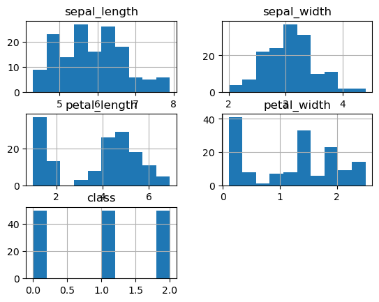

```python
df.hist();
```

**Boxplots and violins**

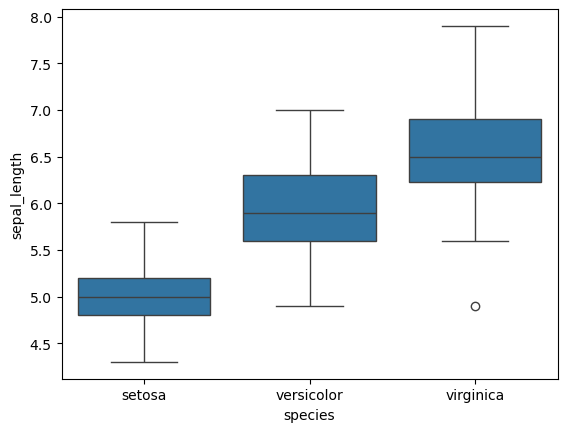

```python
sns.boxplot(x='species', y='sepal_length', data=df)
```

**Mục đích:**  
Đoạn code này vẽ **biểu đồ hộp (boxplot)** để **so sánh phân bố của biến `sepal_length` giữa các loài hoa khác nhau** trong cột `species`.

Cụ thể:

- `x='species'`: trục hoành biểu diễn các loài hoa.
- `y='sepal_length'`: trục tung thể hiện độ dài đài hoa.
- `sns.boxplot(...)`: hiển thị hộp thống kê gồm **giá trị trung vị, tứ phân vị và các điểm ngoại lai (outliers)**.

Biểu đồ giúp **quan sát sự khác biệt trong phân bố giá trị `sepal_length` giữa các loài** và phát hiện các giá trị bất thường.

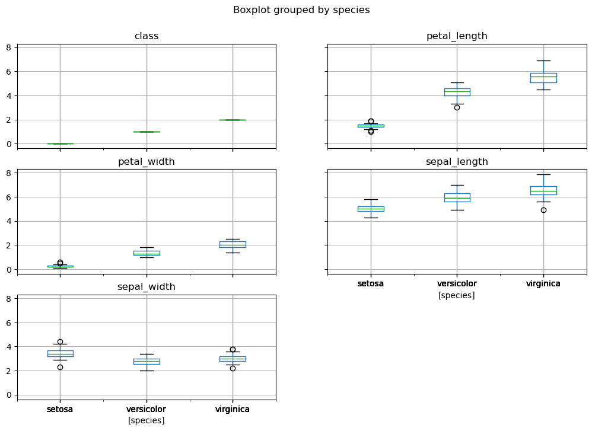

```python
df.boxplot(by="species", figsize=(12, 8));
plt.savefig("a.png", bbox_inches='tight')
```

**Mục đích:**  
Đoạn code này tạo **biểu đồ hộp (boxplot)** cho tất cả các biến số trong DataFrame `df`, **phân nhóm theo biến `species`**, và sau đó **lưu biểu đồ dưới dạng file ảnh “a.png”**.

Cụ thể:

- `df.boxplot(by="species")`: vẽ nhiều boxplot, mỗi cột số liệu được chia theo từng loài hoa.
- `figsize=(12, 8)`: điều chỉnh kích thước biểu đồ để dễ quan sát.
- `plt.savefig("a.png", bbox_inches='tight')`: lưu biểu đồ với bố cục gọn gàng, không bị cắt phần nhãn.

Biểu đồ này giúp **so sánh trực quan phân bố của các biến định lượng giữa các loài hoa**.

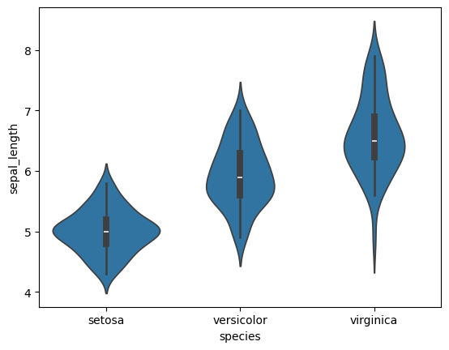

```python
sns.violinplot(x='species', y='sepal_length', data=df)
plt.savefig("violinplot.png", bbox_inches='tight')
```

**Mục đích:**  
Đoạn code này tạo **biểu đồ violin (violin plot)** để hiển thị **phân bố của biến `sepal_length` theo từng loài hoa (`species`)** và **lưu biểu đồ thành file “violinplot.png”**.

Cụ thể:

- `sns.violinplot(...)`: kết hợp đặc điểm của boxplot và biểu đồ mật độ (kernel density) để thể hiện sự phân bố dữ liệu.
- `x='species'`: trục hoành là tên các loài hoa.
- `y='sepal_length'`: trục tung là chiều dài đài hoa.
- `plt.savefig("violinplot.png", bbox_inches='tight')`: lưu lại biểu đồ với bố cục gọn gàng.

Biểu đồ này giúp **quan sát hình dạng, độ lệch và mật độ phân bố của `sepal_length` giữa các loài hoa**.